# Lab #8: Correlation and Linear Models

Helen Huang

11/20/2017

### Due: Nov 22nd

In this lab we will do calculations to better understand the relationship between two quantitative variables: wind speed and temperature. We will use the `airquality` dataset in R. It has environmental measurements from May to September in New York.

You will need some concepts and formulas from day 13 and day 14 lecture slides.

day 13: http://www.stat.ucla.edu/~frederic/13/F16/day14.pdf

day 14: http://www.stat.ucla.edu/~frederic/13/F16/day13.pdf

## 1. Correlation and r^2

1a. Create a scatter plot of Temp vs. Wind (use `plot` with `x = airquality$Wind` and `y = airquality$Temp`). In a sentence, write if this appears to be a positive or negative relationship and how strong it appears to be.

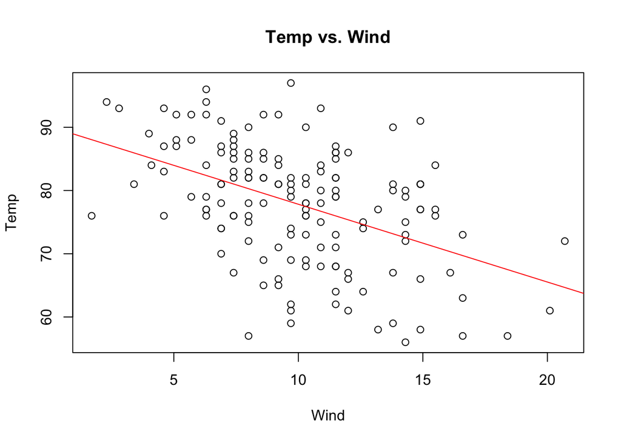

```r
df<-data.frame(airquality)
plot(airquality$Wind, airquality$Temp, main = "Temp vs. Wind", xlab = "Wind", ylab = "Temp")
abline(lm(airquality$Temp ~ airquality$Wind), col = "red")
```

```r
#This appears to be a negative relationship and it appears to be moderate.
```

1b. Calculate the correlation betwen wind and temperature *from scratch* (i.e. you can use the `sum`, `mean`, and `sd` commands in R, but no credit will be given for using a command like `cor` to do the calculation for you. See slide 2 of day 14 lecture.) Based on that calculation, how strong is the assocation between wind and temperature? (See slide 18 of day 13 lecture.)

```r
mean_w = mean(airquality$Wind)
mean_t = mean(airquality$Temp)
sd_w = sd(airquality$Wind)
sd_t = sd(airquality$Temp)
n = length(airquality$Wind)
r = sum(((airquality$Wind-mean_w)/sd_w)*((airquality$Temp-mean_t)/sd_t))/(n-1)
r
```

```
## [1] -0.4579879
```

```r
#The association is only moderate.
```

1c. Using your answer from 1b, calculate and **interpret** the $r^2$ value of the relationship.

```r
determination = r^2
determination
```

```
## [1] 0.2097529
```

```r
#The coefficient of determination indicates that 20.9% of total variation in the temperature can be explained by its linear association with the wind.
```

## 2. Linear Model

2a. We will fit a linear model to the data above *from scratch*. Find the appropriate slope and intercept and write your model formula. (See slide 38 of day 14 lecture.) No credit will be given for using a command like `lm` to do the calculation for you.

```r
slope = r*sd_t/sd_w
slope
```

```
## [1] -1.230479
```

```r
intercept = mean_t-slope*mean_w
intercept
```

```
## [1] 90.13487
```

```r
#Temperature = 90.135 - 1.2305*(Wind)
```

2b. Based on the linear model from 2a, what do we expect the temperature to be when the wind is i) 0 mph? ii) 10 mph? iii) 30 mph? Why should we be careful when using our model to predict temperature when wind is 30mph?

```r
Temp_0 = 90.135 - 1.2305*0
Temp_0
```

```
## [1] 90.135
```

```r
Temp_10 = 90.135 - 1.2305*10
Temp_10
```

```
## [1] 77.83
```

```r
Temp_30 = 90.135 - 1.2305*30
Temp_30
```

```
## [1] 53.22
```

```r
#When the wind is 30mph, it is out of the range of our original data, which ranges from 1.7 to 20.7, so this is extrapolation.
```

2c. The first row of `airquality` has a wind reading of 7.4 and temperature of 67. Based on the linear model from 2a, what is the residual associated with this observation? (See slide 49 of day 13 lecture)

```r
Temp_7.4 = 90.135 - 1.2305*7.4
residual = 67-Temp_7.4
residual
```

```
## [1] -14.0293
```

(Note: While you can’t use the `lm` and `cor` commands to answer the questions above, you may have used them to help check your answers.)

```r
cor(airquality$Temp,airquality$Wind)
```

```
## [1] -0.4579879
```

```r
lm(airquality$Temp ~ airquality$Wind)
```

```
##
## Call:
## lm(formula = airquality$Temp ~ airquality$Wind)
##
## Coefficients:
##     (Intercept)  airquality$Wind
##           90.13            -1.23
```